# PA1_Template.Rmd

mt

October 1, 2017

Github location is https://github.com/mtrinn/RepData_PeerAssessment1.

## Loading and preprocessing data

We load the data activity:

```r
activity=read_csv('activity.csv')
summary(activity)
```

```
##      steps             date               interval
##  Min.   :  0.00   Min.   :2012-10-01   Min.   :   0.0
##  1st Qu.:  0.00   1st Qu.:2012-10-16   1st Qu.: 588.8
##  Median :  0.00   Median :2012-10-31   Median :1177.5
##  Mean   : 37.38   Mean   :2012-10-31   Mean   :1177.5
##  3rd Qu.: 12.00   3rd Qu.:2012-11-15   3rd Qu.:1766.2
##  Max.   :806.00   Max.   :2012-11-30   Max.   :2355.0
##  NA's   :2304
```

```r
head(activity,5)
```

```
## # A tibble: 5 x 3
##   steps       date interval
##   <int>     <date>    <int>
## 1    NA 2012-10-01        0
## 2    NA 2012-10-01        5
## 3    NA 2012-10-01       10
## 4    NA 2012-10-01       15
## 5    NA 2012-10-01       20
```

We remove the NA observations in step:

```r
activitynona <- activity %>% filter(!is.na(steps))
summary(activitynona)
```

```
##      steps             date               interval
##  Min.   :  0.00   Min.   :2012-10-02   Min.   :   0.0
##  1st Qu.:  0.00   1st Qu.:2012-10-16   1st Qu.: 588.8
##  Median :  0.00   Median :2012-10-29   Median :1177.5
##  Mean   : 37.38   Mean   :2012-10-30   Mean   :1177.5
##  3rd Qu.: 12.00   3rd Qu.:2012-11-16   3rd Qu.:1766.2
##  Max.   :806.00   Max.   :2012-11-29   Max.   :2355.0
```

```r
str(activitynona)
```

```
## Classes 'tbl_df', 'tbl' and 'data.frame':    15264 obs. of  3 variables:
##  $ steps   : int  0 0 0 0 0 0 0 0 0 0 ...
##  $ date    : Date, format: "2012-10-02" "2012-10-02" ...
##  $ interval: int  0 5 10 15 20 25 30 35 40 45 ...
##  - attr(*, "spec")=List of 2
##   ..$ cols   :List of 3
##   .. ..$ steps   : list()
##   .. .. ..- attr(*, "class")= chr  "collector_integer" "collector"
##   .. ..$ date    :List of 1
##   .. .. ..$ format: chr ""
##   .. .. ..- attr(*, "class")= chr  "collector_date" "collector"
##   .. ..$ interval: list()
##   .. .. ..- attr(*, "class")= chr  "collector_integer" "collector"
##   ..$ default: list()
##   .. ..- attr(*, "class")= chr  "collector_guess" "collector"
##   ..- attr(*, "class")= chr "col_spec"
```

## What is mean total number of steps taken per day?

We calculate the total number of steps taken per day:

```r
ndaysteps <- activitynona %>% group_by(date) %>% summarize(ssteps=sum(steps))
head(ndaysteps)
```

```
## # A tibble: 6 x 2
##         date ssteps
##       <date>  <int>
## 1 2012-10-02    126
## 2 2012-10-03  11352
## 3 2012-10-04  12116
## 4 2012-10-05  13294
## 5 2012-10-06  15420
## 6 2012-10-07  11015
```

We plot a histogram of the total number of steps taken each day. We calculate first the total number of steps for each day:

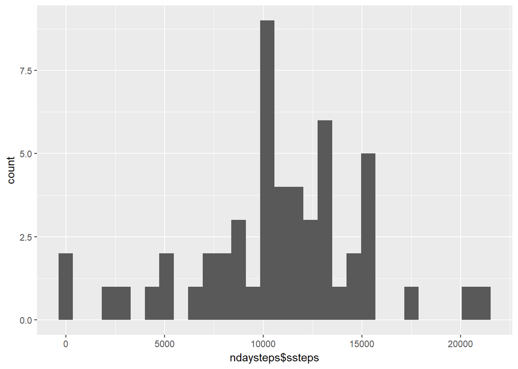

```r
qplot(ndaysteps$ssteps, geom="histogram")
```

We calculate and report the mean and median of the total number of steps taken per day:

```r
nsteps <- activitynona %>% group_by(date) %>% summarize(ssteps=sum(steps)) %>% summarize(mean(ssteps), median(ssteps))
nsteps
```

```
## # A tibble: 1 x 2
##   `mean(ssteps)` `median(ssteps)`
##            <dbl>            <int>
## 1       10766.19            10765
```

```r
# answer is
#  `mean(ssteps)` `median(ssteps)`
#           <dbl>            <int>
#       10766.19            10765
```

## What is the average daily activity pattern?

We calculate the average number of steps per 5-minute interval averaged across all days and plot the average steps (y-axis)against the intervals (x-axis):

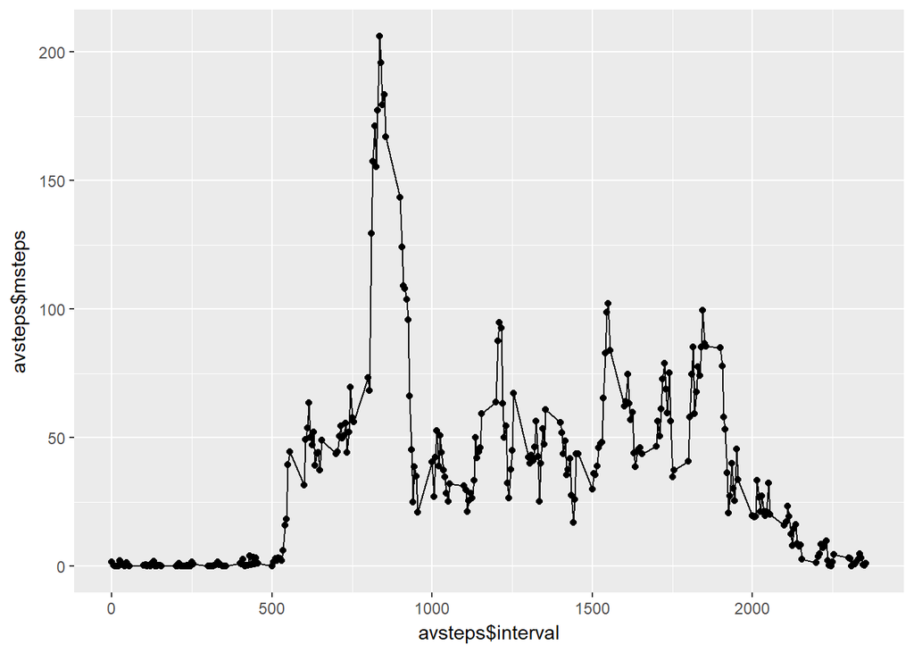

```r
avsteps <- activitynona %>% group_by(interval) %>% summarize(msteps=mean(steps))

qplot(avsteps$interval,avsteps$msteps)+geom_line()
```

We look for the interval with the maximum number of steps:

```r
avsteps[avsteps[,2]==max(avsteps$msteps),]
```

```
## # A tibble: 1 x 2
##   interval   msteps
##      <int>    <dbl>
## 1      835 206.1698
```

```r
# A tibble: 1 x 2
#  interval   msteps
#     <int>    <dbl>
#      835 206.1698
# answer is interval 835
```

## Imputing missing values

We look for the number of missing values, we can use the function summary on the original activity data:

```r
summary(activity)
```

```
##      steps             date               interval
##  Min.   :  0.00   Min.   :2012-10-01   Min.   :   0.0
##  1st Qu.:  0.00   1st Qu.:2012-10-16   1st Qu.: 588.8
##  Median :  0.00   Median :2012-10-31   Median :1177.5
##  Mean   : 37.38   Mean   :2012-10-31   Mean   :1177.5
##  3rd Qu.: 12.00   3rd Qu.:2012-11-15   3rd Qu.:1766.2
##  Max.   :806.00   Max.   :2012-11-30   Max.   :2355.0
##  NA's   :2304
```

```r
 #Min.   :  0.00   Min.   :2012-10-01   Min.   :   0.0
 #1st Qu.:  0.00   1st Qu.:2012-10-16   1st Qu.: 588.8
 #Median :  0.00   Median :2012-10-31   Median :1177.5
 #Mean   : 37.38   Mean   :2012-10-31   Mean   :1177.5
 #3rd Qu.: 12.00   3rd Qu.:2012-11-15   3rd Qu.:1766.2
 #Max.   :806.00   Max.   :2012-11-30   Max.   :2355.0
 #NA's   :2304
# answer: there are 2,304 missing values
```

We can replace missing values by the average number of steps for the interval:

```r
activity1 <- activity %>% group_by(interval) %>% mutate(steps=ifelse(is.na(steps),mean(steps,na.rm=TRUE),steps))
head(activity1,10)
```

```
## # A tibble: 10 x 3
## # Groups:   interval [10]
##        steps       date interval
##        <dbl>     <date>    <int>
##  1 1.7169811 2012-10-01        0
##  2 0.3396226 2012-10-01        5
##  3 0.1320755 2012-10-01       10
##  4 0.1509434 2012-10-01       15
##  5 0.0754717 2012-10-01       20
##  6 2.0943396 2012-10-01       25
##  7 0.5283019 2012-10-01       30
##  8 0.8679245 2012-10-01       35
##  9 0.0000000 2012-10-01       40
## 10 1.4716981 2012-10-01       45
```

We make a histogram of the total number of steps taken each day:

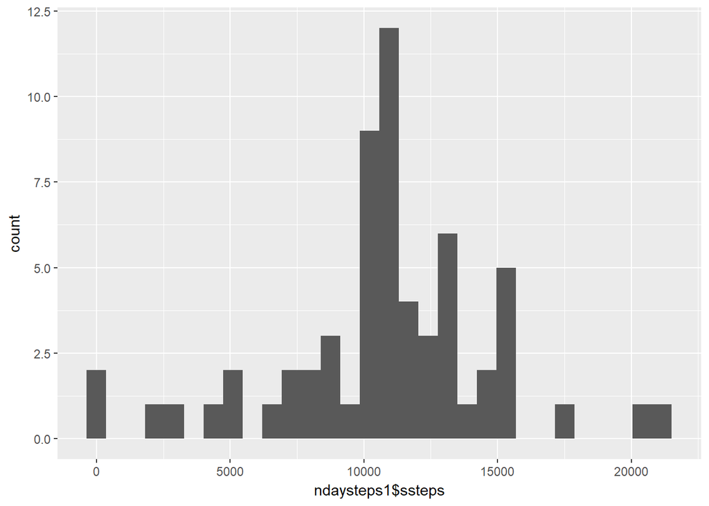

```r
ndaysteps1 <- activity1 %>% group_by(date) %>% summarize(ssteps=sum(steps))

qplot(ndaysteps1$ssteps, geom="histogram")
```

We calculate and report the mean and median total number of steps taken per day.

```r
nsteps1 <- activity1 %>% group_by(date) %>% summarize(ssteps=sum(steps)) %>% summarize(mean(ssteps), median(ssteps))
nsteps1
```

```
## # A tibble: 1 x 2
##   `mean(ssteps)` `median(ssteps)`
##            <dbl>            <dbl>
## 1       10766.19         10766.19
```

```r
# answer:
#`mean(ssteps)` `median(ssteps)`
#           <dbl>            <dbl>
#       10766.19         10766.19
```

## Are there differences in activity patterns between weekdays and weekends?

We create weekday column:

```r
activity2 <- activity1  %>% mutate(day=ifelse((weekdays(date,abbreviate=TRUE)=="Sat" | weekdays(date,abbreviate=TRUE)=="sun"),"weekend","weekday"))
```

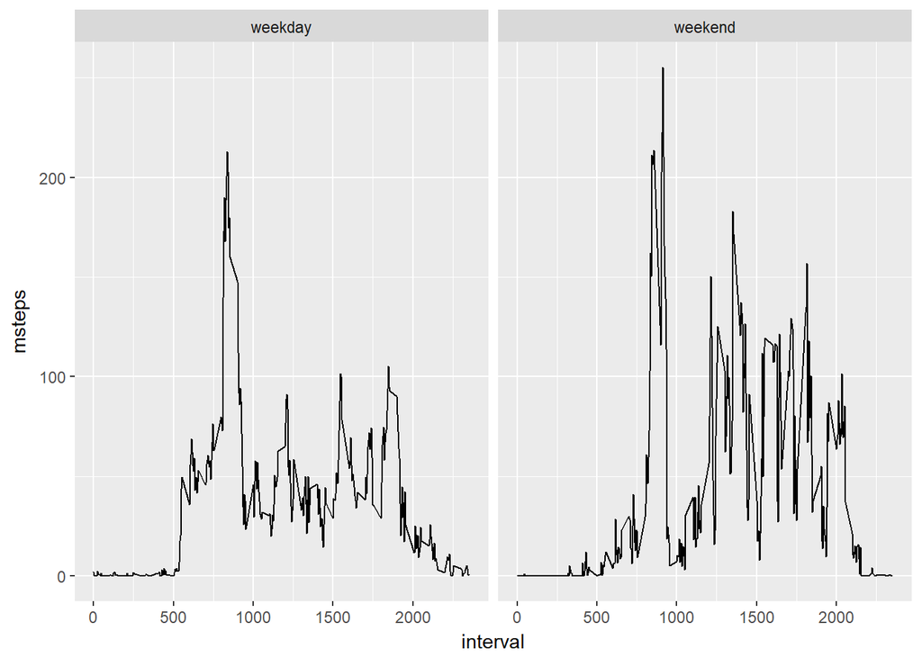

```r
avsteps2 <- activity2 %>% group_by(interval,day) %>% summarize(msteps=mean(steps))

p<-ggplot(avsteps2,aes(interval,msteps))+geom_line()
p + facet_grid(. ~ day)
```

We see during the week there is lot activities in the morning, probably before people go to work. During the weekend, there is also acitivities in the afternoon.